# Trabajo 1: tres series de Energía del Altiplano

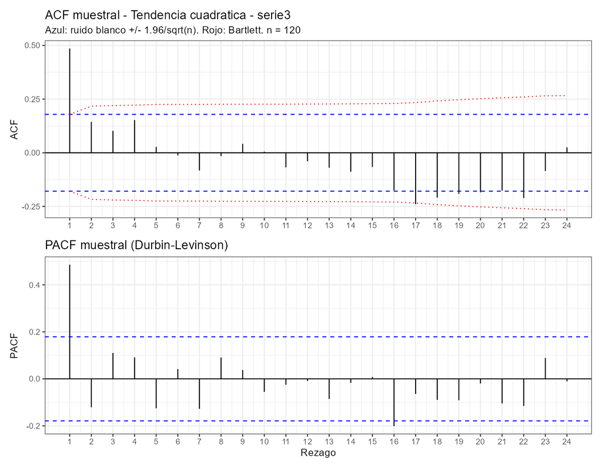

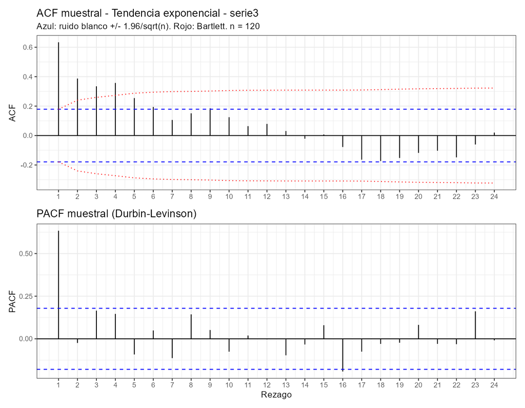

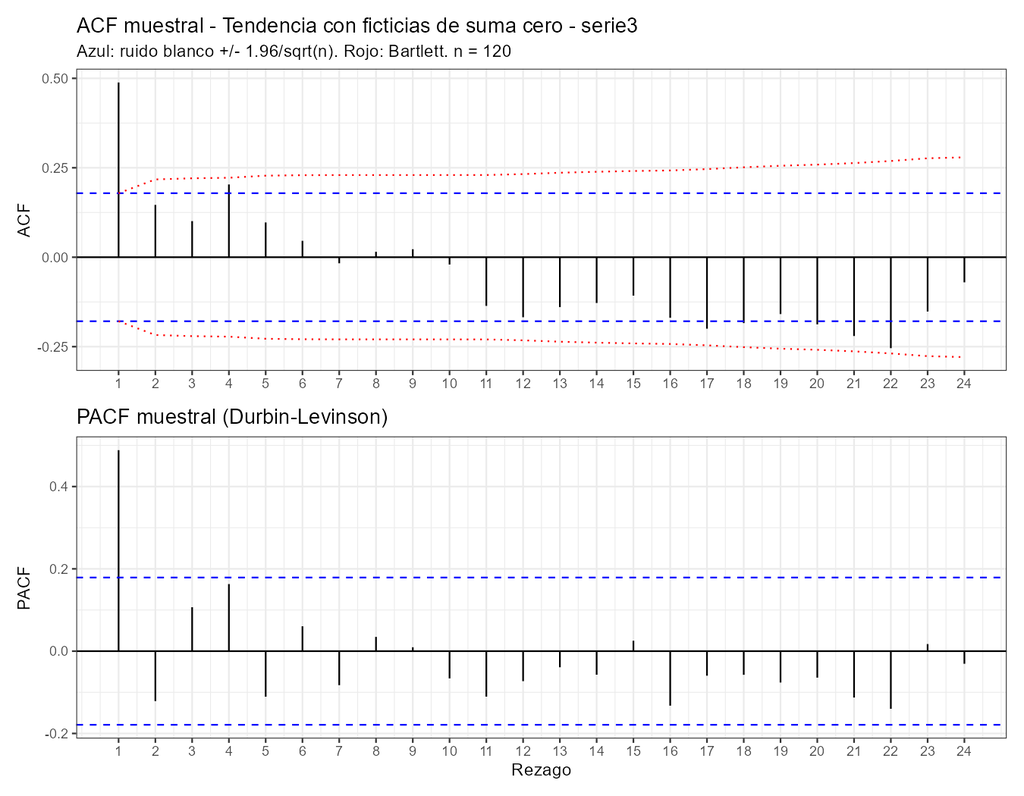

### Normalidad residual

La **prueba de Jarque-Bera** examina conjuntamente la asimetría y la curtosis de los residuos. Sus hipótesis son
$$H_0:S=0\text{ y }K=3\quad\text{(compatibilidad con normalidad)}$$
$$H_1:S\ne0\text{ o }K\ne3\quad\text{(incumplimiento de al menos una condición)}.$$
Si $m_j=n^{-1}\sum_{t=1}^{n}(e_t-\bar e)^j$, la asimetría y la curtosis muestrales son
$$S=\frac{m_3}{m_2^{3/2}},\qquad K=\frac{m_4}{m_2^2},$$
y el estadístico es
$$JB=\frac{n}{6}\left[S^2+\frac{(K-3)^2}{4}\right].$$
Bajo $H_0$ y en muestras grandes, $JB\sim\chi_2^2$. Al 5 %, se rechaza la normalidad si $JB>\chi^2_{0.95;2}=5.991$ o, equivalentemente, si el valor p es menor que 0.05. La tabla presenta las hipótesis mediante las columnas observadas de asimetría y curtosis, el estadístico, sus dos grados de libertad, el valor crítico, el valor p y la decisión.

No rechazar $H_0$ no demuestra que los residuos sean exactamente normales; significa que estas dos características muestrales no aportan evidencia suficiente contra la normalidad. Además, la normalidad es instrumental para inferencia e intervalos y no sustituye la condición sustantiva de residuos sin autocorrelación.

**Ver código**

```r
tabla_normalidad_regresion |>
  select(serie, metodo, escala, JB, gl, valor_critico, valor_p,
         decision, asimetria, curtosis) |>
  knitr::kable(
    col.names = c("Serie", "Metodo", "Escala", "JB", "gl", "Critico",
                  "Valor p", "Decision", "Asimetria", "Curtosis"),
    digits = 4
  )
```

| Serie | Metodo | Escala | JB | gl | Critico | Valor p | Decision | Asimetria | Curtosis |
| --- | --- | --- | --- | --- | --- | --- | --- | --- | --- |
| serie1 | Tendencia con ficticias de suma cero | original | 1.0963 | 2 | 5.9915 | 0.5780 | No rechazar H0 | 0.0808 | 2.5498 |
| serie3 | Tendencia lineal | original | 0.2979 | 2 | 5.9915 | 0.8616 | No rechazar H0 | -0.1167 | 3.0714 |
| serie3 | Tendencia cuadratica | original | 0.3671 | 2 | 5.9915 | 0.8323 | No rechazar H0 | -0.1268 | 3.0952 |
| serie3 | Tendencia exponencial | logaritmica | 2.5818 | 2 | 5.9915 | 0.2750 | No rechazar H0 | -0.3264 | 2.6996 |
| serie3 | Tendencia con ficticias de suma cero | original | 0.4926 | 2 | 5.9915 | 0.7817 | No rechazar H0 | -0.1568 | 2.9849 |

Jarque-Bera no rechaza normalidad en ninguna regresión al 5 %. Esta conclusión no rescata las regresiones de la serie 3 como modelos completos: sus residuos siguen autocorrelacionados según Ljung-Box y Durbin-Watson.

## 6(c) Evaluación por origen móvil

La evaluación simula el uso real del pronóstico mediante una ventana expansiva. El primer origen es $n_0$: se ajusta el modelo con $y_1,\ldots,y_{n_0}$ y se pronostican hasta $H$ períodos. Luego el origen avanza una observación, se incorpora el dato recién disponible, se vuelve a ajustar el modelo con $y_1,\ldots,y_{n_0+1}$ y se repite el proceso. Por tanto, el modelo sí se reestima en cada origen; lo que permanece fijo son los hiperparámetros elegidos exclusivamente en el tramo inicial de estimación, como $k$, $\alpha$, $\beta$ y $\gamma$.

Para cada método se calculan errores $e_{o,h}=y_{o+h}-\hat y_{o+h\mid o}$ sobre los mismos orígenes. En cada horizonte se resumen mediante
$$RMSE_h=\sqrt{\frac{1}{N_h}\sum_o e_{o,h}^2},\qquad
MAD_h=\frac{1}{N_h}\sum_o|e_{o,h}|,$$
$$MAPE_h=\frac{100}{N_h}\sum_o\left|\frac{e_{o,h}}{y_{o+h}}\right|.$$
El RMSE determina el orden de las tablas; MAD y MAPE complementan la lectura con error absoluto y porcentual. La columna *Mejora RMSE (%)* es positiva cuando el método supera al referente y negativa cuando queda por debajo.

Se elige como referente el ingenuo estacional para la serie 1, porque su patrón mensual exige comparar contra el valor del mismo mes anterior. Para las series 2 y 3 se usa el ingenuo ordinario, coherente con la ausencia de estacionalidad material. El referente se calcula sobre exactamente los mismos orígenes que los demás métodos.

**Ver código**

```r
for (k in names(config)) {
  for (h in c(1L, config[[k]]$H)) {
    tb <- tabla_origen_movil |>
      filter(serie == k, horizonte == h) |>
      select(metodo, rol, n_errores, RMSE, MAD, MAPE, mejora_rmse_pct) |>
      arrange(RMSE)
    cat("\n### ", resultados[[k]]$ficha$nombre, ": horizonte $h=", h, "$\n\n", sep = "")
    print(knitr::kable(
      tb,
      col.names = c("Método", "Rol", "Errores", "RMSE", "MAD", "MAPE (%)",
                    "Mejora RMSE (%)"),
      digits = 3
    ))
    cat("\n")
  }
}
```

### Demanda mensual de energia de un distribuidor: horizonte $h=1$

| Método | Rol | Errores | RMSE | MAD | MAPE (%) | Mejora RMSE (%) |
| --- | --- | --- | --- | --- | --- | --- |
| Tendencia con ficticias de suma cero | Aplicado | 29 | 12.319 | 10.248 | 1.352 | 60.146 |
| Holt-Winters aditivo | Aplicado | 29 | 12.894 | 10.028 | 1.320 | 58.288 |
| Holt-Winters multiplicativo | Contraste | 29 | 14.520 | 11.694 | 1.542 | 53.028 |
| Ingenuo estacional | Referente | 29 | 30.911 | 26.159 | 3.442 | 0.000 |

### Demanda mensual de energia de un distribuidor: horizonte $h=12$

| Método | Rol | Errores | RMSE | MAD | MAPE (%) | Mejora RMSE (%) |
| --- | --- | --- | --- | --- | --- | --- |
| Holt-Winters aditivo | Aplicado | 18 | 10.089 | 7.698 | 1.013 | 63.360 |
| Tendencia con ficticias de suma cero | Aplicado | 18 | 10.666 | 9.060 | 1.185 | 61.264 |
| Holt-Winters multiplicativo | Contraste | 18 | 12.604 | 10.621 | 1.390 | 54.226 |
| Ingenuo estacional | Referente | 18 | 27.536 | 24.628 | 3.226 | 0.000 |

### Consumo diario de energia de una estacion de bombeo: horizonte $h=1$

| Método | Rol | Errores | RMSE | MAD | MAPE (%) | Mejora RMSE (%) |
| --- | --- | --- | --- | --- | --- | --- |
| Suavizamiento exponencial simple | Aplicado | 40 | 4.245 | 3.574 | 7.502 | 3.771 |
| Ingenuo | Referente | 40 | 4.411 | 3.678 | 7.705 | 0.000 |
| Media movil | Aplicado | 40 | 4.417 | 3.596 | 7.571 | -0.118 |
| Media simple | Aplicado | 40 | 5.374 | 4.204 | 8.711 | -21.810 |

### Consumo diario de energia de una estacion de bombeo: horizonte $h=7$

| Método | Rol | Errores | RMSE | MAD | MAPE (%) | Mejora RMSE (%) |
| --- | --- | --- | --- | --- | --- | --- |
| Media simple | Aplicado | 34 | 5.766 | 4.549 | 9.409 | 21.211 |
| Suavizamiento exponencial simple | Aplicado | 34 | 7.137 | 5.831 | 12.080 | 2.487 |
| Media movil | Aplicado | 34 | 7.161 | 5.779 | 11.909 | 2.149 |
| Ingenuo | Referente | 34 | 7.319 | 6.047 | 12.554 | 0.000 |

### Usuarios conectados a la red de un operador regional: horizonte $h=1$

| Método | Rol | Errores | RMSE | MAD | MAPE (%) | Mejora RMSE (%) |
| --- | --- | --- | --- | --- | --- | --- |
| Holt | Aplicado | 30 | 6.943 | 5.410 | 1.345 | 7.236 |
| Tendencia cuadratica | Aplicado | 30 | 7.295 | 6.118 | 1.521 | 2.520 |
| Ingenuo | Referente | 30 | 7.484 | 5.740 | 1.425 | 0.000 |
| Tendencia lineal | Aplicado | 30 | 7.599 | 6.388 | 1.592 | -1.530 |
| Doble media movil | Aplicado | 30 | 8.300 | 7.081 | 1.759 | -10.897 |
| Tendencia con ficticias de suma cero | Contraste | 30 | 8.425 | 6.915 | 1.724 | -12.569 |
| Tendencia exponencial | Aplicado | 30 | 19.208 | 17.487 | 4.358 | -156.650 |

### Usuarios conectados a la red de un operador regional: horizonte $h=21$

| Método | Rol | Errores | RMSE | MAD | MAPE (%) | Mejora RMSE (%) |
| --- | --- | --- | --- | --- | --- | --- |
| Tendencia cuadratica | Aplicado | 10 | 7.533 | 5.946 | 1.436 | 74.729 |
| Tendencia lineal | Aplicado | 10 | 8.102 | 6.134 | 1.486 | 72.820 |
| Tendencia con ficticias de suma cero | Contraste | 10 | 9.275 | 6.687 | 1.619 | 68.885 |
| Holt | Aplicado | 10 | 14.091 | 10.733 | 2.592 | 52.727 |
| Doble media movil | Aplicado | 10 | 17.267 | 14.359 | 3.467 | 42.074 |
| Ingenuo | Referente | 10 | 29.809 | 27.890 | 6.696 | 0.000 |
| Tendencia exponencial | Aplicado | 10 | 32.703 | 31.788 | 7.663 | -9.710 |

Las tablas usan 29, 40 y 30 errores a un paso para las series 1, 2 y 3. En el horizonte máximo quedan, respectivamente, 18, 34 y 10, porque los últimos orígenes ya no disponen de una realización futura a distancia $H$. Que un método no supere al referente en esta etapa no lo elimina automáticamente; la selección y validación del ganador corresponden a la iteración siguiente.

- **Serie 1.** La tendencia con ficticias obtiene el menor RMSE a un paso (12.319) y Holt-Winters aditivo en $h=12$ (10.089). Ambos superan ampliamente al ingenuo estacional, lo que muestra el valor de representar conjuntamente tendencia y estacionalidad.
- **Serie 2.** SES encabeza $h=1$ con RMSE 4.245, mientras la media simple encabeza $h=7$ con 5.766. La comparación queda restringida a métodos no estacionales, coherentes con el patrón observado.
- **Serie 3.** Holt presenta el menor RMSE a un paso (6.943) y la tendencia cuadrática en $h=21$ (7.533). La ventaja de las tendencias en el horizonte largo es marcada frente al ingenuo, aunque la decisión definitiva todavía debe pasar por la validación reservada para 6(d).

## 6(d) Validación de los ganadores

El ganador de cada serie es el método con menor RMSE en $h=1$. La validación usa exclusivamente sus errores de origen móvil a un paso, $e_{o,1}=y_{o+1}-\hat y_{o+1\mid o}$; no usa los residuos internos del ajuste. Los ganadores sometidos a diagnóstico son:

**Ver código**

```r
ganadores_h1 |>
  select(serie, metodo, n_errores, RMSE, rmse_referente, mejora_rmse_pct) |>
  knitr::kable(
    col.names = c("Serie", "Ganador", "Errores", "RMSE", "RMSE referente",
                  "Mejora RMSE (%)"),
    digits = 3
  )
```

| Serie | Ganador | Errores | RMSE | RMSE referente | Mejora RMSE (%) |
| --- | --- | --- | --- | --- | --- |
| serie1 | Tendencia con ficticias de suma cero | 29 | 12.319 | 30.911 | 60.146 |
| serie2 | Suavizamiento exponencial simple | 40 | 4.245 | 4.411 | 3.771 |
| serie3 | Holt | 30 | 6.943 | 7.484 | 7.236 |

### Errores en el tiempo y correlogramas

Los gráficos temporales permiten detectar cambios de nivel, dispersión o rachas. En los correlogramas, la banda azul es $\pm1.96/\sqrt{n_e}$ y se calcula separadamente con los 29, 40 y 30 errores disponibles. La banda roja de Bartlett se presenta como referencia adicional para la ACF.

**Serie 1: tendencia con ficticias de suma cero**

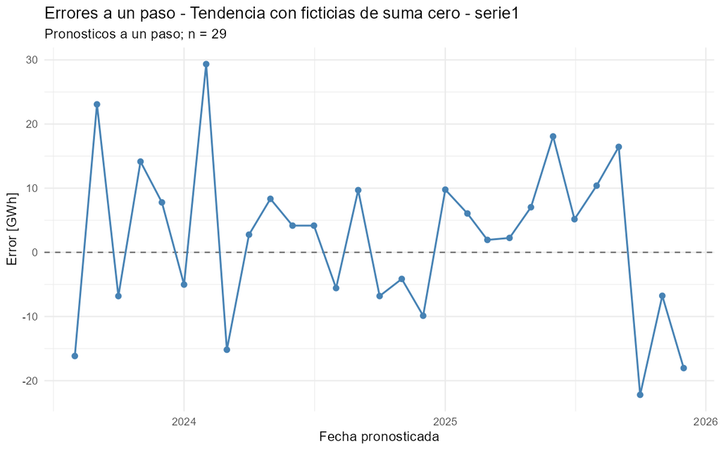

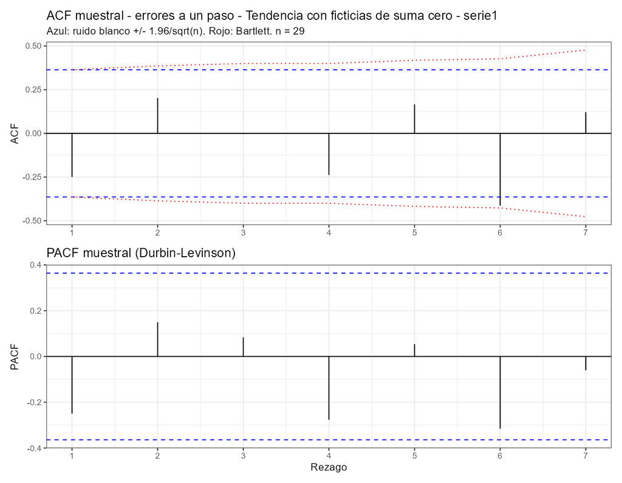

**Serie 2: suavizamiento exponencial simple**

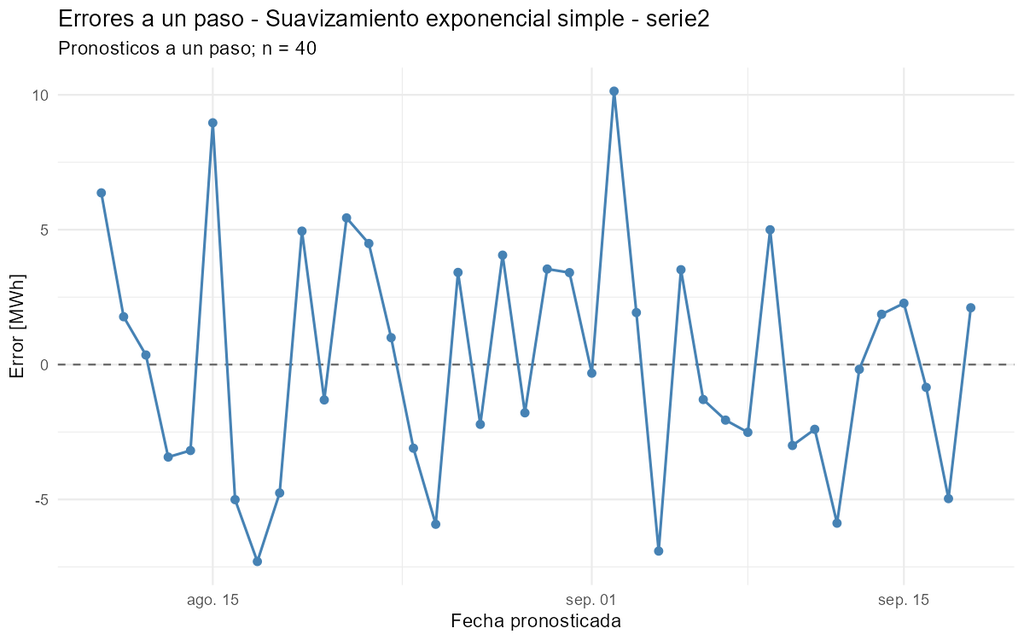

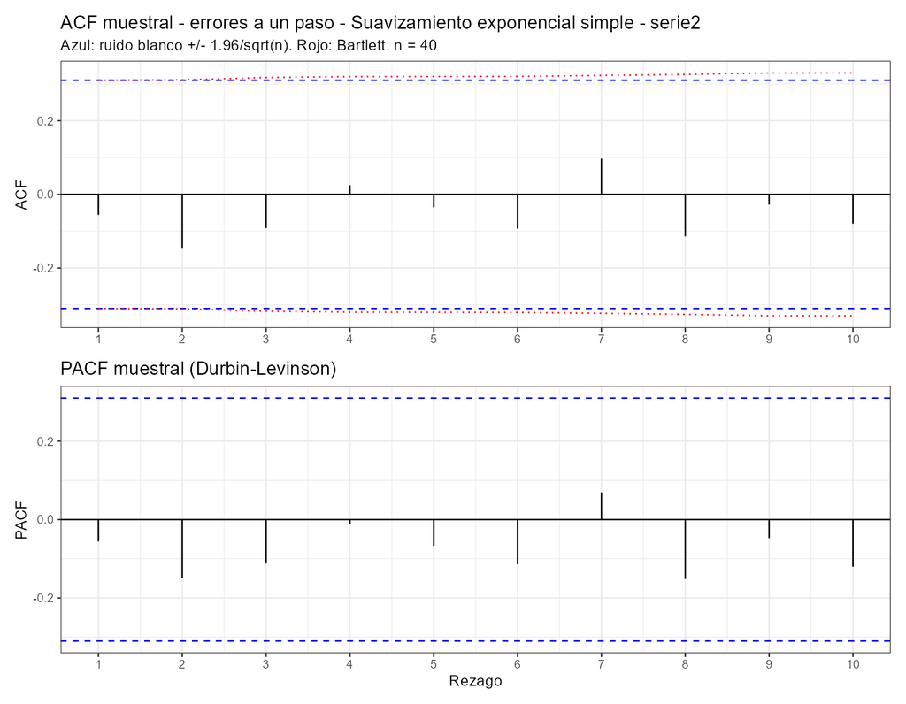

**Serie 3: Holt**

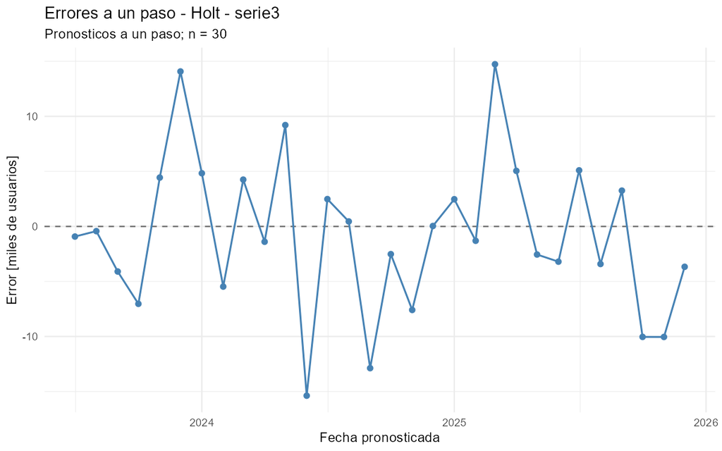

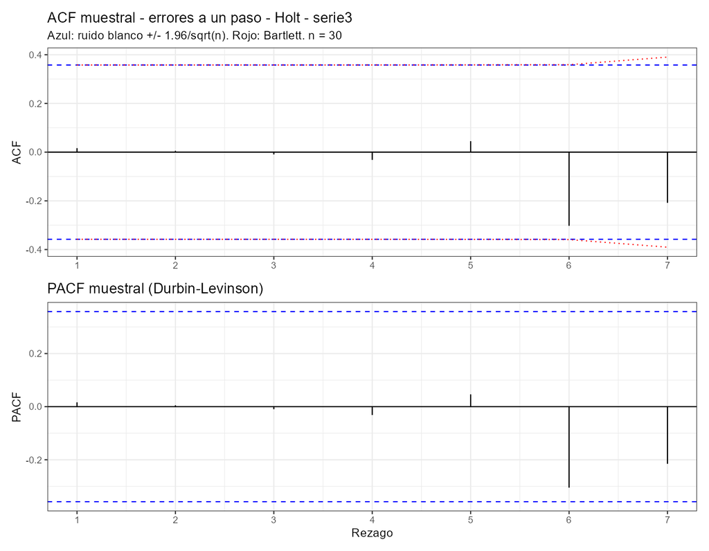

### Prueba t de media cero

Para cada ganador se contrasta
$$H_0:\mu_e=0\qquad\text{contra}\qquad H_1:\mu_e\ne0.$$
El estadístico es
$$t=\frac{\bar e}{s_e/\sqrt{n_e}}\sim t_{n_e-1}\quad\text{bajo }H_0.$$
Al 5 % se rechaza $H_0$ cuando $|t|>t_{0.975;n_e-1}$; el valor crítico se calcula para el tamaño de cada serie y aparece en la tabla junto al estadístico observado, el valor p y la decisión.

**Ver código**

```r
tabla_media_ganadores |>
  select(serie, metodo, n, media, error_estandar, t, gl,
         valor_critico, valor_p, decision) |>
  knitr::kable(
    col.names = c("Serie", "Ganador", "n", "Media", "EE", "t", "gl",
                  "Crítico", "Valor p", "Decisión"),
    digits = 4
  )
```

| Serie | Ganador | n | Media | EE | t | gl | Crítico | Valor p | Decisión |
| --- | --- | --- | --- | --- | --- | --- | --- | --- | --- |
| serie1 | Tendencia con ficticias de suma cero | 29 | 2.2065 | 2.2905 | 0.9633 | 28 | 2.0484 | 0.3436 | No rechazar H0 |
| serie2 | Suavizamiento exponencial simple | 40 | 0.1545 | 0.6793 | 0.2275 | 39 | 2.0227 | 0.8213 | No rechazar H0 |
| serie3 | Holt | 30 | -0.7180 | 1.2823 | -0.5599 | 29 | 2.0452 | 0.5798 | No rechazar H0 |

En ninguna serie se rechaza $H_0$: los valores p son $= 0.3436$, $= 0.8213$ y $= 0.5798$. Por tanto, los errores no muestran sesgo medio estadísticamente detectable; esto significa que los ganadores no tienden sistemáticamente a pronosticar por encima o por debajo de lo observado.

### Prueba de Ljung-Box

Para cada ganador se contrasta
$$H_0:\rho_1=\cdots=\rho_m=0\qquad\text{contra}\qquad
H_1:\text{alguna }\rho_h\ne0.$$
Se usa $m=\min\{\lfloor n_e/4\rfloor,24\}$ y
$$Q_m=n_e(n_e+2)\sum_{h=1}^{m}\frac{r_h^2}{n_e-h}\sim\chi_m^2
\quad\text{bajo }H_0.$$
Los grados de libertad son $m$: no se descuentan parámetros porque se están examinando errores de pronóstico fuera de muestra. Al 5 % se rechaza cuando $Q_m>\chi^2_{0.95;m}$. La tabla incluye hipótesis mediante $m$, estadístico observado, distribución y grados de libertad, valor crítico, valor p y decisión; además registra los rezagos que cruzan individualmente la banda del correlograma.

**Ver código**

```r
tabla_dependencia_ganadores |>
  select(serie, metodo, n, m, banda, rezagos_fuera, Q, gl,
         valor_critico, valor_p, decision) |>
  knitr::kable(
    col.names = c("Serie", "Ganador", "n", "m", "Banda", "Rezagos fuera",
                  "Q", "gl", "Crítico", "Valor p", "Decisión"),
    digits = 4
  )
```

| Serie | Ganador | n | m | Banda | Rezagos fuera | Q | gl | Crítico | Valor p | Decisión |
| --- | --- | --- | --- | --- | --- | --- | --- | --- | --- | --- |
| serie1 | Tendencia con ficticias de suma cero | 29 | 7 | 0.3640 | 6 | 13.7119 | 7 | 14.0671 | 0.0565 | No rechazar H0 |
| serie2 | Suavizamiento exponencial simple | 40 | 10 | 0.3099 | Ninguno | 3.5130 | 10 | 18.3070 | 0.9667 | No rechazar H0 |
| serie3 | Holt | 30 | 7 | 0.3578 | Ninguno | 5.6006 | 7 | 14.0671 | 0.5871 | No rechazar H0 |

No se rechaza ausencia conjunta de autocorrelación en ninguna serie. En las series 2 y 3 ningún rezago cruza siquiera la banda individual. En la serie 1 aparece una señal aislada en el rezago 6, compatible con una oscilación semestral débil que la tendencia con efectos mensuales fijos no reproduce completamente; sin embargo, Ljung-Box queda apenas por debajo de la región de rechazo ($Q=13.712$ frente a 14.067$, valor p $= 0.0565$), por lo que no se concluye que permanezca dependencia conjunta al 5 %.

### Prueba de Jarque-Bera

La normalidad se contrasta mediante
$$H_0:S=0\text{ y }K=3\qquad\text{contra}\qquad
H_1:S\ne0\text{ o }K\ne3,$$
con
$$JB=\frac{n_e}{6}\left[S^2+\frac{(K-3)^2}{4}\right]\sim\chi_2^2
\quad\text{bajo }H_0.$$
Al 5 % se rechaza cuando $JB>\chi^2_{0.95;2}=5.991$. La tabla presenta el estadístico observado, sus dos grados de libertad, valor crítico, valor p, decisión y las dos características muestrales que originan la prueba.

**Ver código**

```r
tabla_normalidad_ganadores |>
  select(serie, metodo, JB, gl, valor_critico, valor_p,
         decision, asimetria, curtosis) |>
  knitr::kable(
    col.names = c("Serie", "Ganador", "JB", "gl", "Crítico", "Valor p",
                  "Decisión", "Asimetría", "Curtosis"),
    digits = 4
  )
```

| Serie | Ganador | JB | gl | Crítico | Valor p | Decisión | Asimetría | Curtosis |
| --- | --- | --- | --- | --- | --- | --- | --- | --- |
| serie1 | Tendencia con ficticias de suma cero | 0.1630 | 2 | 5.9915 | 0.9217 | No rechazar H0 | 0.0057 | 2.6329 |
| serie2 | Suavizamiento exponencial simple | 0.9976 | 2 | 5.9915 | 0.6073 | No rechazar H0 | 0.2560 | 2.4200 |
| serie3 | Holt | 0.1161 | 2 | 5.9915 | 0.9436 | No rechazar H0 | 0.1511 | 3.0401 |

Jarque-Bera no rechaza normalidad para ninguno de los tres ganadores. Los errores son compatibles con asimetría cero y curtosis tres al 5 %, sin que “no rechazar” constituya una demostración de normalidad exacta.

### Durbin-Watson

Como diagnóstico adicional se calcula
$$d=\frac{\sum_{i=2}^{n_e}(e_i-e_{i-1})^2}{\sum_{i=1}^{n_e}e_i^2}
\approx2(1-r_1).$$
No se usa como una prueba separada: un valor próximo a 2 es compatible con ausencia de autocorrelación de primer orden, uno menor que 2 sugiere dependencia positiva y uno mayor que 2, negativa.

**Ver código**

```r
tabla_dw_ganadores |>
  select(serie, metodo, r1, DW, aproximacion_DW) |>
  knitr::kable(
    col.names = c("Serie", "Ganador", "r1", "DW", "2(1-r1)"),
    digits = 4
  )
```

| Serie | Ganador | r1 | DW | 2(1-r1) |
| --- | --- | --- | --- | --- |
| serie1 | Tendencia con ficticias de suma cero | -0.2497 | 2.2495 | 2.4994 |
| serie2 | Suavizamiento exponencial simple | -0.0557 | 2.0498 | 2.1114 |
| serie3 | Holt | 0.0164 | 1.9402 | 1.9673 |

SES y Holt presentan valores muy cercanos a 2, coherentes con sus correlogramas y con Ljung-Box. En la serie 1, $DW=2.250$ sugiere una dependencia negativa leve de primer orden, pero no suficiente para producir rechazo conjunto. En suma, los tres ganadores superan la validación exigida en $h=1$; la señal semestral aislada de la serie 1 debe conservarse como limitación del modelo.

## 6(e) Pronóstico final

Cada ganador se reajusta una sola vez con todas las observaciones de su serie, conservando los hiperparámetros elegidos exclusivamente en el tramo inicial. Desde el origen final $T$ se generan los $H$ pronósticos requeridos. Para cada horizonte $h$, la dispersión se estima con la desviación $s_h$ de los errores de origen móvil del ganador en ese mismo horizonte y se representa mediante
$$\hat y_{T+h\mid T}\pm1.96s_h.$$
Esta banda es **heurística**: resume la variabilidad empírica observada en la evaluación y cambia con el horizonte, pero no es un intervalo de confianza ni un intervalo probabilístico formal. En particular, no incorpora explícitamente incertidumbre de parámetros ni garantiza una cobertura del 95 %.

### Serie 1: demanda mensual de energía

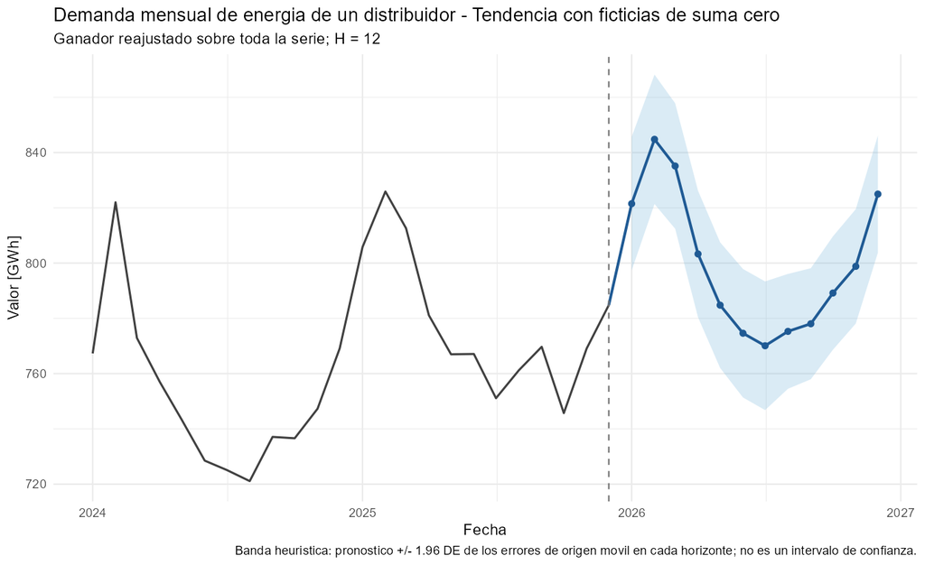

**Ver código**

```r
tabla_pronosticos_finales |>
  filter(serie == "serie1") |>
  select(horizonte, fecha, pronostico, desviacion_error,
         limite_inferior, limite_superior) |>
  knitr::kable(
    col.names = c("h", "Fecha", "Pronóstico", "DE errores", "Límite inferior",
                  "Límite superior"),
    digits = 2
  )
```

| h | Fecha | Pronóstico | DE errores | Límite inferior | Límite superior |
| --- | --- | --- | --- | --- | --- |
| 1 | 2026-01-01 | 821.50 | 12.33 | 797.32 | 845.67 |
| 2 | 2026-02-01 | 844.79 | 11.95 | 821.37 | 868.21 |
| 3 | 2026-03-01 | 835.13 | 11.59 | 812.41 | 857.84 |
| 4 | 2026-04-01 | 803.30 | 11.68 | 780.40 | 826.20 |
| 5 | 2026-05-01 | 784.77 | 11.60 | 762.03 | 807.51 |
| 6 | 2026-06-01 | 774.61 | 11.87 | 751.36 | 797.87 |
| 7 | 2026-07-01 | 770.08 | 11.88 | 746.80 | 793.36 |
| 8 | 2026-08-01 | 775.29 | 10.61 | 754.50 | 796.07 |
| 9 | 2026-09-01 | 778.05 | 10.25 | 757.95 | 798.14 |
| 10 | 2026-10-01 | 789.16 | 10.47 | 768.65 | 809.68 |
| 11 | 2026-11-01 | 798.82 | 10.56 | 778.12 | 819.52 |
| 12 | 2026-12-01 | 824.97 | 10.82 | 803.76 | 846.18 |

La tendencia con ficticias conserva el perfil mensual: el máximo pronosticado es 844.8 GWh y el mínimo 770.1 GWh. La banda utiliza una desviación distinta para cada mes de 2026, estimada con los errores históricos del horizonte correspondiente.

### Serie 2: consumo diario de la estación de bombeo

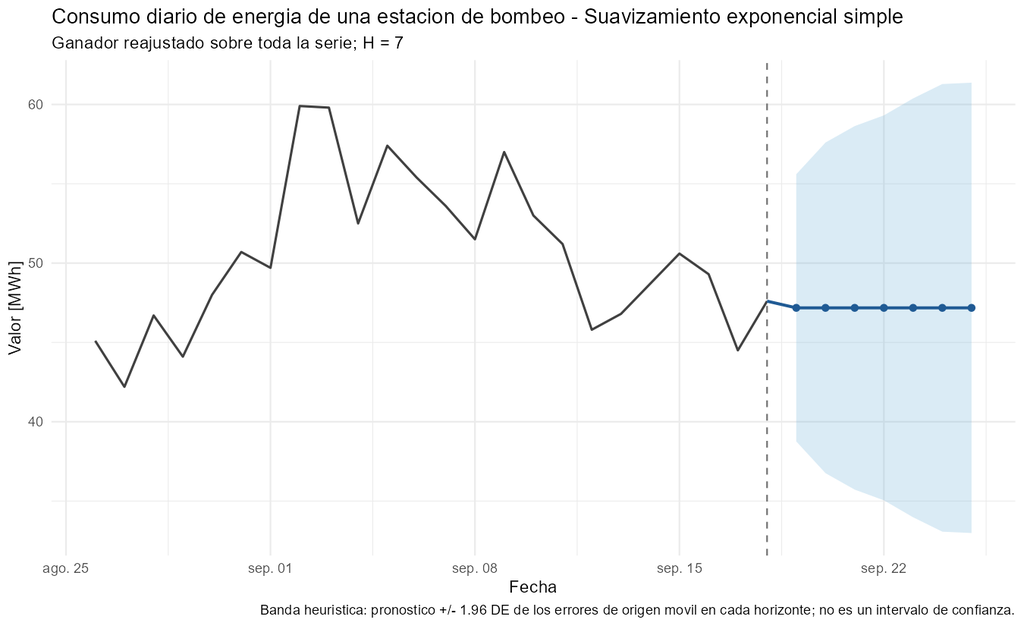

**Ver código**

```r
tabla_pronosticos_finales |>
  filter(serie == "serie2") |>
  select(horizonte, fecha, pronostico, desviacion_error,
         limite_inferior, limite_superior) |>
  knitr::kable(
    col.names = c("h", "Fecha", "Pronóstico", "DE errores", "Límite inferior",
                  "Límite superior"),
    digits = 2
  )
```

| h | Fecha | Pronóstico | DE errores | Límite inferior | Límite superior |
| --- | --- | --- | --- | --- | --- |
| 1 | 2025-09-19 | 47.18 | 4.30 | 38.76 | 55.60 |
| 2 | 2025-09-20 | 47.18 | 5.32 | 36.76 | 57.60 |
| 3 | 2025-09-21 | 47.18 | 5.85 | 35.72 | 58.64 |
| 4 | 2025-09-22 | 47.18 | 6.19 | 35.05 | 59.31 |
| 5 | 2025-09-23 | 47.18 | 6.74 | 33.98 | 60.38 |
| 6 | 2025-09-24 | 47.18 | 7.20 | 33.07 | 61.29 |
| 7 | 2025-09-25 | 47.18 | 7.24 | 32.98 | 61.37 |

SES produce un nivel constante de 47.18 MWh para los siete días. Aunque el pronóstico puntual no cambia, la banda se ensancha con el horizonte porque la dispersión empírica de los errores aumenta de 4.30 a 7.24 MWh.

### Serie 3: usuarios conectados

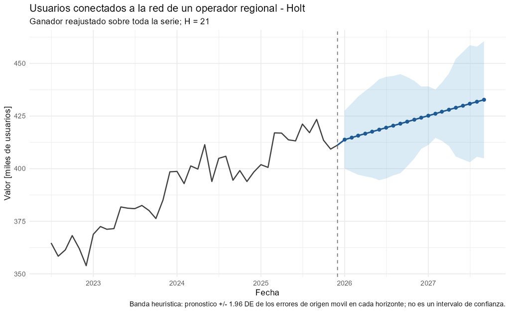

**Ver código**

```r
tabla_pronosticos_finales |>
  filter(serie == "serie3") |>
  select(horizonte, fecha, pronostico, desviacion_error,
         limite_inferior, limite_superior) |>
  knitr::kable(
    col.names = c("h", "Fecha", "Pronóstico", "DE errores", "Límite inferior",
                  "Límite superior"),
    digits = 2
  )
```

| h | Fecha | Pronóstico | DE errores | Límite inferior | Límite superior |
| --- | --- | --- | --- | --- | --- |
| 1 | 2026-01-01 | 413.80 | 7.02 | 400.03 | 427.56 |
| 2 | 2026-02-01 | 414.75 | 8.31 | 398.47 | 431.02 |
| 3 | 2026-03-01 | 415.69 | 9.47 | 397.12 | 434.26 |
| 4 | 2026-04-01 | 416.64 | 10.36 | 396.34 | 436.94 |
| 5 | 2026-05-01 | 417.59 | 11.15 | 395.73 | 439.45 |
| 6 | 2026-06-01 | 418.54 | 12.25 | 394.53 | 442.54 |
| 7 | 2026-07-01 | 419.48 | 12.31 | 395.35 | 443.62 |
| 8 | 2026-08-01 | 420.43 | 12.06 | 396.79 | 444.07 |
| 9 | 2026-09-01 | 421.38 | 12.01 | 397.84 | 444.92 |
| 10 | 2026-10-01 | 422.33 | 10.84 | 401.09 | 443.57 |
| 11 | 2026-11-01 | 423.28 | 9.41 | 404.83 | 441.72 |
| 12 | 2026-12-01 | 424.22 | 7.55 | 409.42 | 439.03 |
| 13 | 2027-01-01 | 425.17 | 7.10 | 411.26 | 439.08 |
| 14 | 2027-02-01 | 426.12 | 5.87 | 414.62 | 437.62 |
| 15 | 2027-03-01 | 427.07 | 7.05 | 413.24 | 440.89 |
| 16 | 2027-04-01 | 428.01 | 8.80 | 410.77 | 445.26 |
| 17 | 2027-05-01 | 428.96 | 11.84 | 405.75 | 452.17 |
| 18 | 2027-06-01 | 429.91 | 13.04 | 404.35 | 455.47 |
| 19 | 2027-07-01 | 430.86 | 14.19 | 403.05 | 458.66 |
| 20 | 2027-08-01 | 431.81 | 13.35 | 405.64 | 457.98 |
| 21 | 2027-09-01 | 432.75 | 14.19 | 404.93 | 460.57 |

Holt prolonga el crecimiento reciente desde 413.8 hasta 432.8 mil usuarios. La banda debe leerse únicamente como rango heurístico de error histórico. Con este ganador la trayectoria puntual no llega a 450 mil usuarios dentro de los 21 meses, aunque el límite superior de la banda lo supera desde el mes 17. La decisión sobre el transformador se toma en el punto 8 con el método de menor error a 21 meses, la tendencia cuadrática.

# 7. Conclusión técnica

Los resultados se sintetizan utilizando las transformaciones diagnosticadas en los puntos 4 y 5 y los errores de origen móvil del punto 6. En cada horizonte se comparan métodos evaluados sobre los mismos orígenes.

**Ver código**

```r
resumen_conclusiones <- tabla_origen_movil |>
  dplyr::group_by(serie, horizonte) |>
  dplyr::slice_min(RMSE, n = 1, with_ties = FALSE) |>
  dplyr::ungroup() |>
  dplyr::select(serie, horizonte, metodo, RMSE, rmse_referente, mejora_rmse_pct)
knitr::kable(resumen_conclusiones, digits = 2,
  col.names = c("Serie", "Horizonte", "Ganador", "RMSE", "RMSE referente", "Mejora (%)"))
```

| Serie | Horizonte | Ganador | RMSE | RMSE referente | Mejora (%) |
| --- | --- | --- | --- | --- | --- |
| serie1 | 1 | Tendencia con ficticias de suma cero | 12.32 | 30.91 | 60.15 |
| serie1 | 12 | Holt-Winters aditivo | 10.09 | 27.54 | 63.36 |
| serie2 | 1 | Suavizamiento exponencial simple | 4.25 | 4.41 | 3.77 |
| serie2 | 7 | Media simple | 5.77 | 7.32 | 21.21 |
| serie3 | 1 | Holt | 6.94 | 7.48 | 7.24 |
| serie3 | 21 | Tendencia cuadratica | 7.53 | 29.81 | 74.73 |

## Serie 1. Demanda mensual de energía

La demanda mensual presenta tendencia creciente y estacionalidad anual aditiva ($s=12$; la correlación entre la media y la desviación de cada año es 0.014). La transformación $(1-B^{12})Y_t$ permite analizar diferencias entre meses equivalentes de años consecutivos y produce una serie plausiblemente estacionaria. A un paso, la tendencia con ficticias estacionales obtuvo el menor RMSE: **12.32 GWh**, frente a **30.91 GWh** del referente, una mejora del **60.15 %**. Su pendiente estimada es aproximadamente **1.97 GWh por mes**, con efectos mensuales que permiten reflejar diferencias entre estaciones. Para doce meses, el mejor resultado corresponde a Holt-Winters aditivo, con $\alpha=\beta=\gamma=0.1$: RMSE de **10.09 GWh**, frente a **27.54 GWh**, una mejora del **63.36 %**. Su actualización gradual de nivel, pendiente y estacionalidad es compatible con el patrón observado, aunque su ventaja queda establecida por la evaluación empírica. En los errores del ganador a un paso aparece una señal aislada en el rezago 6; la prueba conjunta de Ljung-Box no rechaza ausencia de autocorrelación al 5 % (valor p **0.0565**), por lo que se interpreta como una limitación potencial y no como dependencia conjunta confirmada.

## Serie 2. Consumo diario de energía

El consumo fluctúa alrededor de un nivel estable de 47.74 MWh, sin tendencia ni estacionalidad semanal: las medias por día de la semana difieren a lo sumo 0.69 MWh, frente a una desviación de la serie de 4.74 MWh. Se conserva la serie sin diferenciar, porque $(1-B)$ solo reduce la varianza por efecto de $r_1 = 0.63$, no porque haya una tendencia que quitar. Para un día gana el suavizamiento exponencial simple (SES), con $\alpha=0.8$ y RMSE de **4.25 MWh**, frente a **4.41 MWh** del ingenuo, una mejora del **3.77 %**. El valor alto de $\alpha$ da mayor peso a las observaciones recientes. Para siete días gana la media simple, sin parámetros, con RMSE de **5.77 MWh**, frente a **7.32 MWh**, una mejora del **21.21 %**: al alargar el horizonte, el nivel promedio es una referencia más estable que el último valor. En los errores de SES a un paso no queda estructura: ningún rezago sale de la banda y la prueba de Ljung-Box no rechaza ausencia de autocorrelación (valor p **0.9667**).

## Serie 3. Usuarios conectados a la red

El número de usuarios crece sostenidamente y sin estacionalidad anual: la amplitud de los índices estacionales (5.42 mil) es menor que la desviación del residuo (5.77 mil). La transformación $(1-B)Y_t$ elimina la tendencia y deja incrementos mensuales plausiblemente estacionarios, con media de 1.36 mil usuarios por mes. A un mes gana Holt, con $\alpha=0.55$ y $\beta=0.05$, RMSE de **6.94 miles de usuarios**, frente a **7.48**, una mejora del **7.24 %**. A veintiún meses gana la tendencia cuadrática, con RMSE de **7.53 miles de usuarios**, frente a **29.81**, una mejora del **74.73 %**. La regresión cuadrática tiene coeficientes de 1.58 para $t$ y -0.000422 para $t^2$; este último no es significativo al 5 % con el error robusto, de modo que su elección para el horizonte largo se apoya en el error de pronóstico fuera del tramo de estimación y no en una curvatura demostrada. En los errores de Holt a un paso no queda estructura: ningún rezago sale de la banda y la prueba de Ljung-Box no rechaza ausencia de autocorrelación (valor p **0.5871**).

## Comparación general

La demanda mensual requiere representar tendencia y estacionalidad: en ella ganaron la tendencia con ficticias a un mes (**12.32 GWh**) y Holt-Winters aditivo a doce meses (**10.09 GWh**). En la estación de bombeo, sin tendencia ni estación, SES gana a un día (**4.25 MWh**) y la media simple a siete días (**5.77 MWh**). Para los usuarios, Holt gana a un mes (**6.94 miles**) y la tendencia cuadrática a veintiún meses (**7.53 miles**). El ganador de una serie pierde en otra porque cada método supone una estructura distinta. La tendencia con ficticias gana en la serie 1, donde la estación existe, pero en la serie 3, aplicada como contraste, queda detrás del ingenuo a un paso (8.42 frente a 7.48 mil). Un pronóstico plano funciona en la serie 2, que no tiene tendencia, pero en la serie 3 acumula error con el horizonte: el ingenuo llega a un RMSE de 29.81 mil a veintiún meses. Y entre los métodos de tendencia importa cómo extrapolan: Holt gana a un mes en la serie 3, pero con $\beta=0.05$ su pendiente final es baja y a veintiún meses su RMSE sube a 14.09 mil, casi el doble del de la cuadrática; la tendencia exponencial, que supone crecimiento proporcional, es la peor de la serie (19.21 mil a un mes). Los RMSE de horizontes distintos no se comparan entre sí, porque provienen de orígenes distintos.

# 8. Argumentos para los interesados

Esta sección traduce los resultados estadísticos a las decisiones de contratación de energía y ampliación de infraestructura, con los costos descritos en el contexto del trabajo.

## 8(a) Mapa de interesados

### Serie 1. Demanda mensual de energía

La **gerencia comercial** determina cuántos GWh contratar por mes en 2026. La **junta directiva** aprueba la estrategia y asume su riesgo financiero. La **superintendencia** vigila los costos que pueden trasladarse a tarifas, mientras que los **usuarios** pueden verse afectados por esos sobrecostos. Un déficit de contratación se paga con un sobrecosto del **35 %** y un excedente se liquida con pérdida del **20 %** de su valor. El costo relativo de déficit es 1.75 veces el de excedente, por unidad comparable; sin un precio base por GWh no cabe calcular el valor absoluto en pesos.

### Serie 2. Consumo diario de energía

La **mesa de compras** contrata la energía para los siete días siguientes; el **jefe de operación** planifica la actividad de bombeo y la **gerencia financiera** administra el presupuesto. Los **usuarios de las tres veredas** dependen del servicio de agua, aunque no se puede cuantificar aquí un traslado del costo energético. Frente al precio contratado de 420 COP/kWh, comprar faltantes a 780 COP/kWh añade **360.000 COP/MWh**, mientras que vender sobrantes a 250 COP/kWh ocasiona una pérdida de **170.000 COP/MWh**. Por cada MWh de error, el déficit cuesta aproximadamente **2.12 veces** el excedente.

### Serie 3. Usuarios conectados

La **gerencia de planeación** decide cuándo ordenar el transformador; la **junta directiva** autoriza la inversión de **6.800 millones de COP**, y el **área de operación** organiza su instalación. Los **usuarios** dependen de la continuidad del servicio y el **regulador** puede intervenir ante incumplimientos. Una compra prematura inmoviliza capital, pero una compra tardía puede dejar la red por encima de los **450 mil usuarios** durante los **nueve meses** que tarda la instalación. El contexto no cuantifica en pesos las interrupciones ni las posibles sanciones.

## 8(b) Argumentos para los interesados

### Serie 1. Demanda mensual de energía

**Afirmación.** Contratar cantidades diferentes para cada mes de 2026, prestando particular atención al riesgo de déficit.

**Evidencia.** Holt-Winters aditivo obtuvo RMSE de **10.09 GWh** a doce meses frente a **27.54 GWh** del referente, una reducción del **63.36 %**. Sus cantidades estimadas para 2026 van aproximadamente de **771 a 845 GWh por mes**, como muestra la nota de interesados.

**Justificación.** Un contrato uniforme ignoraría el patrón anual. Además, un faltante cuesta el 35 % adicional y un excedente pierde el 20 % de su valor: los costos de equivocarse en cada dirección son distintos.

**Alcance.** Esta recomendación corresponde a 2026 bajo un patrón de demanda comparable al histórico. El pronóstico es una referencia y no determina, por sí solo, la contratación de costo mínimo.

**Objeción.** ¿Por qué no elegir el ganador a un mes? La tendencia con ficticias obtuvo **12.32 GWh** a un paso; sin embargo, para contratar todo el año importa la evaluación a doce meses, donde Holt-Winters obtuvo **10.09 GWh**. Son comparaciones dentro de horizontes distintos.

### Serie 2. Consumo diario de energía

**Afirmación.** Usar el promedio de consumo como referencia para contratar los siete días siguientes y vigilar los déficits, porque son más costosos.

**Evidencia.** La media simple obtuvo a siete días RMSE de **5.77 MWh**, frente a **7.32 MWh** del referente, una mejora del **21.21 %**. El pronóstico para el período 19–25 de septiembre de 2025 es aproximadamente **47.7 MWh diarios**.

**Justificación.** La serie fluctúa alrededor de un nivel estable. Por cada 5 MWh faltantes, el costo adicional sería **1.800.000 COP**, frente a **850.000 COP** de pérdida por 5 MWh sobrantes. Minimizar RMSE no equivale necesariamente a minimizar el costo de compras.

**Alcance.** La referencia corresponde a la semana que sigue al último dato; debe actualizarse ante cambios de operación o de consumo. No representa por sí misma una cantidad económicamente óptima.

**Objeción.** ¿Por qué la media simple y no SES? SES ganó a un día (**4.25 MWh**), pero para el horizonte de siete días la media simple consiguió el menor error (**5.77 MWh**).

### Serie 3. Usuarios conectados a la red

**Afirmación.** Revisar durante 2026 la autorización del transformador para no esperar a superar los 450 mil usuarios antes de solicitarlo.

**Evidencia.** La tendencia cuadrática obtuvo a veintiún meses RMSE de **7.53 miles de usuarios**, frente a **29.81** del referente, una mejora del **74.73 %**. La trayectoria puntual alcanza los **450 mil usuarios en septiembre de 2027**; restando nueve meses, la orden orientativa sería en **diciembre de 2026**.

**Justificación.** Esperar a alcanzar el umbral dejaría nueve meses sin capacidad nueva. La ampliación cuesta 6.800 millones de COP; las consecuencias monetarias del retraso no se pueden precisar con el contexto disponible.

**Alcance.** El resultado depende de que continúe una dinámica de crecimiento semejante a la observada. La fecha de cruce es una estimación puntual, no una garantía ni una probabilidad de sobrecarga.

**Objeción.** ¿Por qué utilizar la tendencia cuadrática si su curvatura no es significativa? Porque el criterio para la decisión fue el error de pronóstico a veintiún meses (**7.53 miles**), no la significancia aislada de un coeficiente. La incertidumbre sobre el mes exacto exige revisar la proyección periódicamente.

## 8(c) Nota para los interesados

Se elaboró una nota independiente de **una página**, dirigida a las personas que toman y ejecutan las decisiones y a quienes resultan afectados. Presenta un gráfico por serie, las cantidades de referencia, los costos de equivocarse por exceso o defecto y los límites de las proyecciones, sin fórmulas ni lenguaje técnico del curso.

**Documento de entrega:** Ver nota para los interesados (PDF).

Los gráficos se elaboraron con los métodos que obtuvieron el menor RMSE en el horizonte correspondiente a cada decisión, distintos en algunos casos de los ganadores a un paso utilizados en el punto 6(e).

# Bloques de verificación

```
>>> BLOQUES DE VERIFICACION
- diferenciar(d = 1) vs diff(): 0
- diferenciar(D = 1, s = 12) vs diff(lag = 12): 0
- diferenciar(d = 1, D = 1, s = 12) vs diff(diff(lag = 12)): 0
- serie1 | ACF vs acf(): 4.440892e-16 | PACF Durbin-Levinson vs pacf(): 1.017242e-14 | Menor que 1e-10: TRUE
- serie2 | ACF vs acf(): 2.220446e-16 | PACF Durbin-Levinson vs pacf(): 8.049117e-16 | Menor que 1e-10: TRUE
- serie3 | ACF vs acf(): 6.661338e-16 | PACF Durbin-Levinson vs pacf(): 2.620733e-14 | Menor que 1e-10: TRUE
- ajustar_tendencia(lineal) vs lm(): 8.526513e-14
- pruebas-metodos-faltantes.R : todas las pruebas pasaron
- pruebas-metodos-reciclables.R : todas las pruebas pasaron
- pruebas-optimizacion-asignacion.R : todas las pruebas pasaron
```